# Income distribution by age

Use `sample_size_tb` to examine the age distribution, income distributions by year and age, and how closely log income follows a normal distribution. For individuals aged 26–60 in 2020, calculate the age composition of those whose income exceeds a threshold.

## 1 Distributions of individual age and income

```r
library(tidyverse)
library(pins)

# Specify relative paths for the board, figure output directory, and plotting theme.
board <- board_folder("../income_board_replicate")
graph_dir <- "graph"
dir.create(graph_dir, recursive = TRUE, showWarnings = FALSE)
source("theme_ipsum_like.R")
theme_set(theme_ipsum())
```

**Loading data and creating age classes**

Load income data `sample_size_tb` and select observations with positive income `main_var`.

Calculate individual age `age` as observation year `year` minus the birth year in the first four characters of `birth_date`. Define `age_class` as `age_20` for ages 20 and under, `age_25` for ages 21–25, and subsequent five-year classes through `age_80` for ages 76–80. Assign observations above age 80 or with missing age to `age_other`.

```r
sample_size_tb <- board |> pin_read("sample_size_tb") |>
  filter(main_var > 0)

size_age_tb <- sample_size_tb |>
  mutate(
    age = as.numeric(year) - as.numeric(str_sub(birth_date, 1, 4)),
    age_class = case_when(
      age <= 20 ~ "age_20",
      age <= 80 ~ str_c("age_", 5 * ceiling(age / 5)),
      TRUE ~ "age_other"
    )
  )

age_class_labels <- c(
  "age_20" = "0–20",
  "age_25" = "21–25", "age_30" = "26–30", "age_35" = "31–35", "age_40" = "36–40",
  "age_45" = "41–45", "age_50" = "46–50", "age_55" = "51–55", "age_60" = "56–60"
)
```

**Age distribution**

Plot a histogram with one-year bins for observations aged 20–100 in 2020.

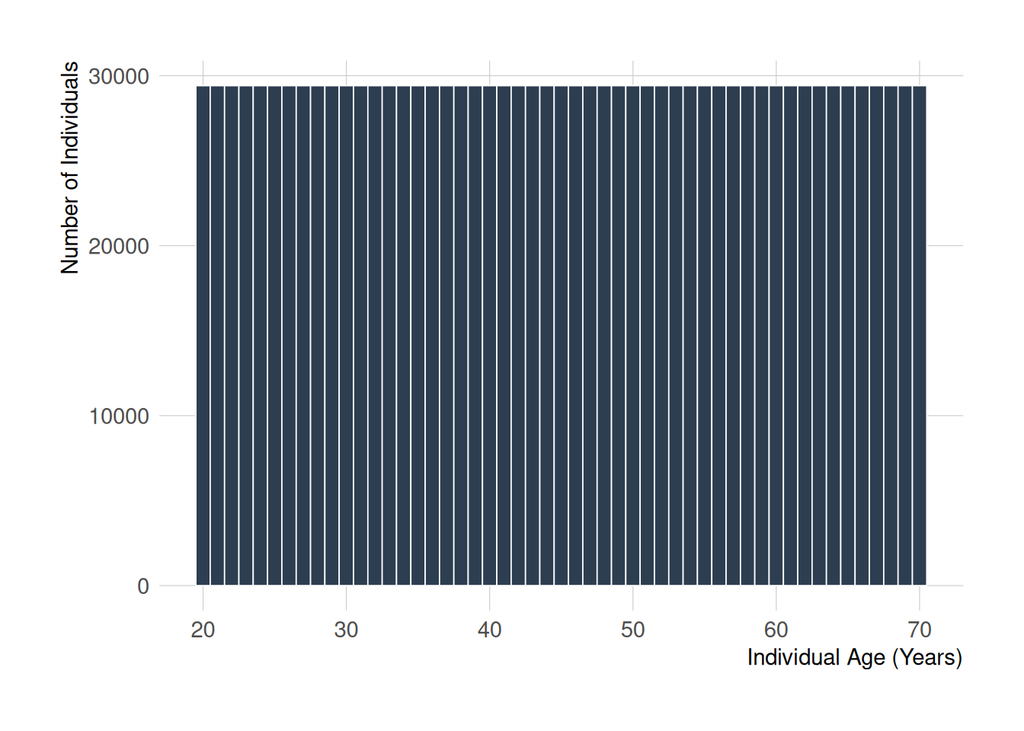

```r
size_age_tb |>
  filter(
    year == "2020",
    age >= 20, age <= 100
  ) |>
ggplot(aes(age)) +
  geom_histogram(binwidth = 1,
                 fill = "#2C3E50", color = "white",
                 linewidth = 0.3) +
  labs(
    x = "Individual Age (Years)",
    y = "Number of Individuals"
  ) +
  theme(
    panel.grid.minor = element_blank()
  )
ggsave(filename = "age_dist_income.png", path = graph_dir)
```

**Annual comparison of income distributions**

Compare income density curves by year using the positive-income observations selected when loading the data. Impose no additional age restrictions. Use base-10 logarithmic scales on both axes, with displayed income in yen ranging from $10^3$ to $10^{10}$ and density from $10^{-6}$ to $10^0$.

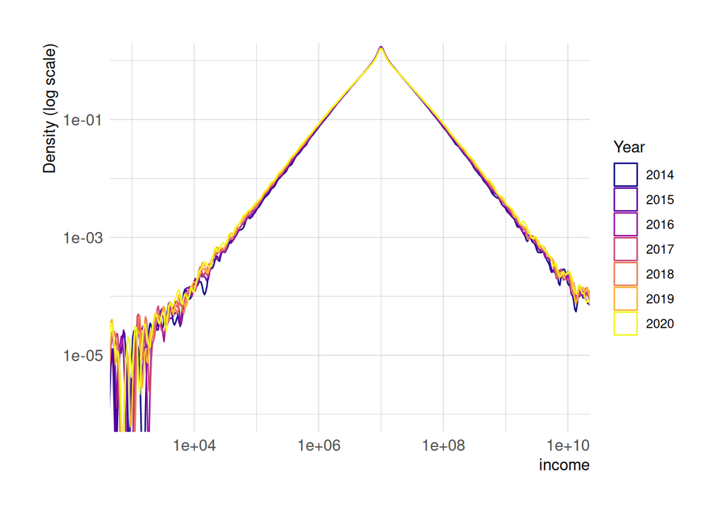

```r
sample_size_tb |>
  ggplot() +
  geom_density(aes(main_var, color = year)) +
  scale_color_viridis_d(option = "C") +
  scale_x_log10() +
  scale_y_log10() +
  coord_cartesian(xlim = c(10^3, 10^{10}), ylim = c(10^{-6}, 10^0)) +
  labs(
    x = "income",
    y = "Density (log scale)",
    color = "Year"
  )
ggsave(filename = "main_var_df_log.png", path = graph_dir)
```

**Income distribution by age**

For observations aged 26–60 in 2020, compare income distributions across seven age classes: 26–30, 31–35, …, 56–60. As in the annual comparison, estimate the density of base-10 log income and use logarithmic scales on both axes. Display income in yen from $10^3$ to $10^9$ and density from $10^{-5}$ to $10^0$.

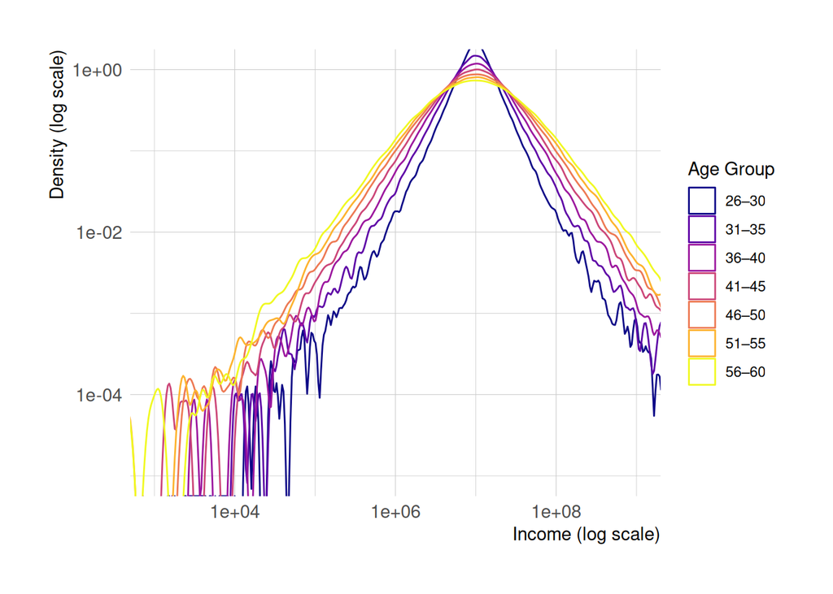

```r
size_age_tb |>
  filter(year == "2020",
         age >= 26, age <= 60) |>
  ggplot() +
  geom_density(aes(main_var, color = age_class)) +
  scale_color_viridis_d(
    option = "C",
    labels = age_class_labels
    ) +
  scale_x_log10() +
  scale_y_log10() +
  coord_cartesian(xlim = c(10^3, 10^9), ylim = c(10^{-5}, 10^0)) +
  labs(
    x = "Income (log scale)",
    y = "Density (log scale)",
    color = "Age Group",
  )
ggsave(filename = "main_var_df_age_class_log.png", path = graph_dir)
```

## 2 Comparing log income with a normal distribution: Q-Q plots

Select the seven age classes `age_30`, `age_35`, …, `age_60` (ages 26–60) from the 2020 data. For each class, take the natural logarithm of income in yen, subtract its median, and divide by the MAD.

The standardized value is $z=(\log(Y)-\operatorname{median}(\log(Y)))/\operatorname{MAD}(\log(Y))$, where $Y$ is `main_var`.

Use Q-Q plots to compare sample quantiles of standardized log income with theoretical quantiles of the standard normal distribution. Add a reference line with intercept zero and slope one.

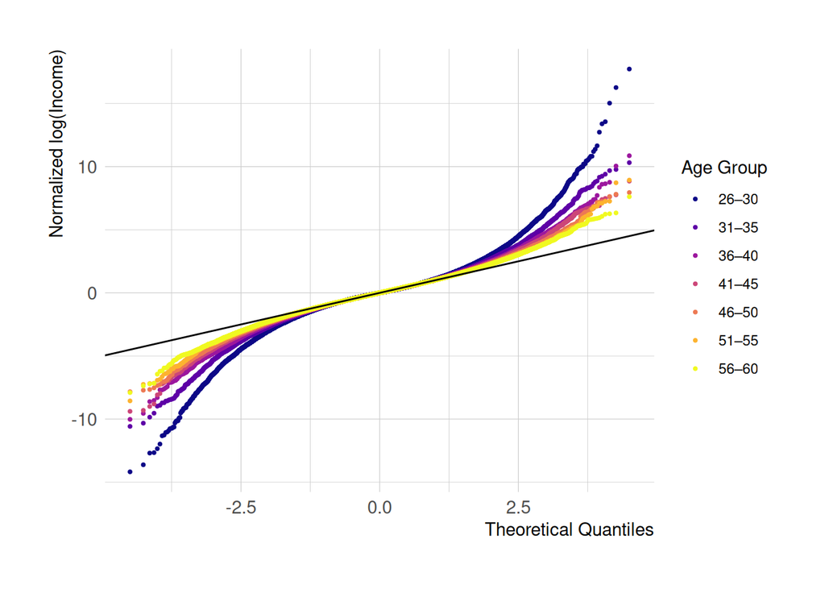

```r
size_age_tb |>
  filter(year == "2020",
         age_class %in% c("age_30", "age_35", "age_40",
                          "age_45", "age_50", "age_55", "age_60"),
         main_var > 0) |>
  group_by(age_class) |>
  mutate(log_size = log(main_var),
         log_size_normalized = (log_size - median(log_size))/mad(log_size) ) |>
ggplot(aes(sample = log_size_normalized, color = age_class)) +
  stat_qq(size = 0.7) + #stat_qq_line() +
  scale_color_viridis_d(
    option = "C",
    labels = age_class_labels
  ) +
  geom_abline(intercept = 0, slope = 1, color="black") +
  labs(
    x = "Theoretical Quantiles",
    y = "Normalized log(Income)",
    color = "Age Group"
  )
ggsave(filename = "income_size_qqplot_by_age.png", path = graph_dir)
```

## 3 Age composition by income threshold

For individuals aged 26–60 in 2020, examine the age composition of those whose income exceeds a threshold.

Set income thresholds `criteria` in yen to $10^{6.6}, 10^{6.8}, \ldots, 10^{10}$, giving 18 points spaced by 0.2 in base-10 logarithms. First restrict the data to 2020 and ages 26–60, then select observations with `main_var` strictly above each threshold. Calculate composition shares `n_ratio`, using the total count `n_total` as the denominator and the count in each age class as the numerator.

```r
# Threshold vector (10^i)
x_val <- 10 ^ seq(6.6, 10, 0.2)

# Use observations aged 26–60 in 2020.
target_tb <- size_age_tb |>
  filter(year == "2020", age >= 26, age <= 60)

frac2_tb <- map_dfr(x_val, function(criteria) {
  sub_tb <- target_tb |> filter(main_var > criteria)

  n_total <- nrow(sub_tb)
  if (n_total == 0) return(NULL)

  sub_tb |>
    count(age_class, name = "n") |>
    transmute(
      age_class,
      n_ratio = n / n_total,
      criteria = criteria,
      n_total = n_total
    )
})
```

**Plotting the shares**

For thresholds with more than 1,000 qualifying individuals (`n_total`), plot age-class shares using points and lines. Show the income threshold in yen on a logarithmic horizontal axis and the composition share on the vertical axis, with a displayed range of 0–0.3.

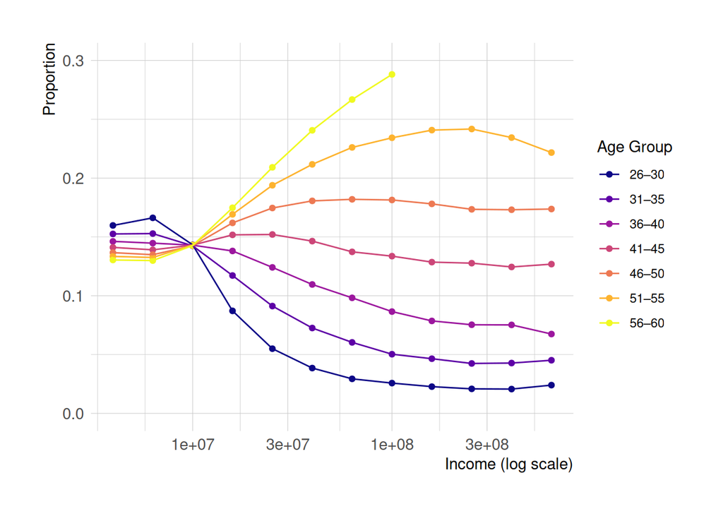

```r
frac2_tb |>
  filter(n_total > 10^3) |>
  ggplot(aes(criteria, n_ratio, color = age_class)) +
    geom_point() +
    geom_line() +
    scale_color_viridis_d(
      option = "C",
      labels = age_class_labels
    ) +
    scale_x_log10() +
    labs(
      x = "Income (log scale)",
      y = "Proportion",
      color = "Age Group"
    ) +
    ylim(c(0, .3))
ggsave(filename = "frac2_age_main_var_middile.png", path = graph_dir)
```